# FitBit fitness tracker

Tales Gomes

02/09/2021

## Sumario das tarefas

Este projeto tem como objetivo encontrar tendências de uso dos usuários para assim ajudar a melhorar o comportamento do *Bellabeat* (Aplicativo do medidor de saúde da Bellabeat).

## Preparação e processamento dos dados

### Descrição dos dados

Será utilizado o banco de dados do fitibit do [kaggle](https://www.kaggle.com/arashnic/fitbit), o qual é composto por 18 planilhas contendo dados de atividades, passos, calorias, sono e batimento cardíaco de uma lista de usuários que consentiram em compartilhas as informações. O banco de dados está sob a licença [CC0: Public Domain](https://creativecommons.org/publicdomain/zero/1.0/). Sendo que para esta tarefa especifica foi escolhido trabalhar com dados diários fornecidos pelos usuários, sendo utilizadas seguintes as tabelas:

- *“dailyActivity_merged”* que contém dados de atividades diárias, como distância percorrida, passos, calorias gastas, tempo sedentário e de atividades leves, moderadas ou avançadas;
- *“sleepDay_merged”* que contém informações de quantidade de sono, tempo na deitado cama e número de eventos de sono;
- *“heartrate_seconds_merged”* que contém o registro dos batimentos cardíacos dos usuários por segundo;
- *“weightLogInfo_merged”* que contém informações sobre peso, índice de massa corporal e percentual de gordura corporal.

### Descrição da processo de limpeza dos dados

Para desempenhar esta análise foi escolhido a linguagem de programação [R](https://www.r-project.org/) e para o tratamento de dados foram seguidos os seguintes passos:

- Todas as tabelas foram carregadas no plataforma;
- Em cada tabela a coluna responsável pelo armazenamento da data do registro foi alterada do tipo string para o tipo data, tendo seus nomes alterados para “date” afim de facilitar a manipulação dos dados;
- Na tabela *“heartrate_seconds_merged”* foi alterada a escala temporal de segundos para diário e calculado a média de batimentos cardíacos por dia;
- Foi feita a união das tabelas através de uma *left-join* entre a tabela *“dailyActivity_merged”* e as outras 3 tabelas;
- Todas as planilhas de tempo foram alteradas de minutos para horas;
- A coluna que contém o ID dos usuários foi alterada para algo mais legível, foi escolhido o prefixo “U” seguido por um numeral. Como por exemplo “U1” para usuário 1;
- A ordem das colunas foi alterada para que colunas correlacionadas fiquem adjacente uma a outra;
- O resultado foi salvo na numa variável e numa planilha *Excel* chamadas *“daily_data”*.

```r
daily_data <- reduce(list(daily_activity,
                          heartrate,
                          daily_sleep,
                          weight_log
                          ),
                     left_join,
                     by = c("id", "date")) |>
  mutate(id = as.factor(id),
         day_of_the_week = lubridate::wday(date,
                                           label = TRUE),
         total_time_asleep = total_minutes_asleep/60,
         total_time_in_bed = total_time_in_bed/60,
         sedentary_time = sedentary_minutes/60,
         lightly_active_time = lightly_active_minutes/60,
         fairly_active_time = fairly_active_minutes/60,
         very_active_time = very_active_minutes/60,
         id = fct_relabel(id, ~ paste0('U', 1:33))
         ) |>
  select(-c(total_minutes_asleep, sedentary_minutes, lightly_active_minutes,
            fairly_active_minutes, very_active_minutes, log_id,
            is_manual_report, weight_pounds, fat, logged_activities_distance)) |>
  relocate(where(is.numeric), .after = last_col())
```

## Análise e visualização

### Resumo dos dados

A tabela resultante pode ser encontrada a seguir:

| id | date | day_of_the_week | total_steps | total_distance | tracker_distance | very_active_distance | moderately_active_distance | light_active_distance | sedentary_active_distance | calories | heartrate | total_sleep_records | total_time_in_bed | weight_kg | bmi | total_time_asleep | sedentary_time | lightly_active_time | fairly_active_time | very_active_time |
| --- | --- | --- | --- | --- | --- | --- | --- | --- | --- | --- | --- | --- | --- | --- | --- | --- | --- | --- | --- | --- |
| U1 | 2016-04-12 | ter | 13162 | 8.50 | 8.50 | 1.88 | 0.55 | 6.06 | 0.00 | 1985 | NA | 1 | 5.766667 | NA | NA | 5.4500000 | 12.13333333 | 5.46666667 | 0.21666667 | 0.41666667 |
| U1 | 2016-04-13 | qua | 10735 | 6.97 | 6.97 | 1.57 | 0.69 | 4.71 | 0.00 | 1797 | NA | 2 | 6.783333 | NA | NA | 6.4000000 | 12.93333333 | 3.61666667 | 0.31666667 | 0.35000000 |
| U1 | 2016-04-14 | qui | 10460 | 6.74 | 6.74 | 2.44 | 0.40 | 3.91 | 0.00 | 1776 | NA | NA | NA | NA | NA | NA | 20.30000000 | 3.01666667 | 0.18333333 | 0.50000000 |
| U1 | 2016-04-15 | sex | 9762 | 6.28 | 6.28 | 2.14 | 1.26 | 2.83 | 0.00 | 1745 | NA | 1 | 7.366667 | NA | NA | 6.8666667 | 12.10000000 | 3.48333333 | 0.56666667 | 0.48333333 |
| U1 | 2016-04-16 | sáb | 12669 | 8.16 | 8.16 | 2.71 | 0.41 | 5.04 | 0.00 | 1863 | NA | 2 | 6.116667 | NA | NA | 5.6666667 | 12.88333333 | 3.68333333 | 0.16666667 | 0.60000000 |
| U1 | 2016-04-17 | dom | 9705 | 6.48 | 6.48 | 3.19 | 0.78 | 2.51 | 0.00 | 1728 | NA | 1 | 11.866667 | NA | NA | 11.6666667 | 8.98333333 | 2.73333333 | 0.33333333 | 0.63333333 |
| U1 | 2016-04-18 | seg | 13019 | 8.59 | 8.59 | 3.25 | 0.64 | 4.71 | 0.00 | 1921 | NA | NA | NA | NA | NA | NA | 19.15000000 | 3.88333333 | 0.26666667 | 0.70000000 |
| U1 | 2016-04-19 | ter | 15506 | 9.88 | 9.88 | 3.53 | 1.32 | 5.03 | 0.00 | 2035 | NA | 1 | 5.333333 | NA | NA | 5.0666667 | 12.91666667 | 4.40000000 | 0.51666667 | 0.83333333 |
| U1 | 2016-04-20 | qua | 10544 | 6.68 | 6.68 | 1.96 | 0.48 | 4.24 | 0.00 | 1786 | NA | 1 | 6.283333 | NA | NA | 6.0000000 | 13.63333333 | 3.41666667 | 0.20000000 | 0.46666667 |
| U1 | 2016-04-21 | qui | 9819 | 6.34 | 6.34 | 1.34 | 0.35 | 4.65 | 0.00 | 1775 | NA | 1 | 6.066667 | NA | NA | 5.4166667 | 13.96666667 | 3.51666667 | 0.13333333 | 0.31666667 |

[output cut: 933 more lines]

### Sumário dos dados

Data summary

| Name | daily_data |
| --- | --- |
| Number of rows | 943 |
| Number of columns | 21 |
| Key | NULL |
| _______________________ |  |
| Column type frequency: |  |
| Date | 1 |
| factor | 2 |
| numeric | 18 |
| ________________________ |  |
| Group variables | None |

**Variable type: Date**

| skim_variable | n_missing | complete_rate | min | max | median | n_unique |
| --- | --- | --- | --- | --- | --- | --- |
| date | 0 | 1 | 2016-04-12 | 2016-05-12 | 2016-04-26 | 31 |

**Variable type: factor**

| skim_variable | n_missing | complete_rate | ordered | n_unique | top_counts |
| --- | --- | --- | --- | --- | --- |
| id | 0 | 1 | FALSE | 33 | U16: 32, U19: 32, U30: 32, U1: 31 |
| day_of_the_week | 0 | 1 | TRUE | 7 | ter: 152, qua: 150, qui: 148, sex: 126 |

**Variable type: numeric**

| skim_variable | n_missing | complete_rate | mean | sd | p0 | p25 | p50 | p75 | p100 | hist |
| --- | --- | --- | --- | --- | --- | --- | --- | --- | --- | --- |
| total_steps | 0 | 1.00 | 7652.19 | 5086.53 | 0.00 | 3795.00 | 7439.00 | 10734.00 | 36019.00 | ▇▇▁▁▁ |
| total_distance | 0 | 1.00 | 5.50 | 3.93 | 0.00 | 2.62 | 5.26 | 7.72 | 28.03 | ▇▆▁▁▁ |
| tracker_distance | 0 | 1.00 | 5.49 | 3.91 | 0.00 | 2.62 | 5.26 | 7.71 | 28.03 | ▇▆▁▁▁ |
| very_active_distance | 0 | 1.00 | 1.50 | 2.66 | 0.00 | 0.00 | 0.22 | 2.06 | 21.92 | ▇▁▁▁▁ |
| moderately_active_distance | 0 | 1.00 | 0.57 | 0.88 | 0.00 | 0.00 | 0.24 | 0.81 | 6.48 | ▇▁▁▁▁ |
| light_active_distance | 0 | 1.00 | 3.35 | 2.05 | 0.00 | 1.95 | 3.38 | 4.79 | 10.71 | ▆▇▆▁▁ |
| sedentary_active_distance | 0 | 1.00 | 0.00 | 0.01 | 0.00 | 0.00 | 0.00 | 0.00 | 0.11 | ▇▁▁▁▁ |
| calories | 0 | 1.00 | 2307.51 | 720.82 | 0.00 | 1829.50 | 2140.00 | 2796.50 | 4900.00 | ▁▆▇▃▁ |
| heartrate | 608 | 0.36 | 78.56 | 10.64 | 59.38 | 70.44 | 77.44 | 84.90 | 109.79 | ▆▇▇▃▁ |
| total_sleep_records | 530 | 0.44 | 1.12 | 0.35 | 1.00 | 1.00 | 1.00 | 1.00 | 3.00 | ▇▁▁▁▁ |
| total_time_in_bed | 530 | 0.44 | 7.64 | 2.12 | 1.02 | 6.72 | 7.72 | 8.77 | 16.02 | ▁▃▇▁▁ |
| weight_kg | 876 | 0.07 | 72.04 | 13.92 | 52.60 | 61.40 | 62.50 | 85.05 | 133.50 | ▇▃▃▁▁ |
| bmi | 876 | 0.07 | 25.19 | 3.07 | 21.45 | 23.96 | 24.39 | 25.56 | 47.54 | ▇▁▁▁▁ |
| total_time_asleep | 530 | 0.44 | 6.99 | 1.97 | 0.97 | 6.02 | 7.22 | 8.17 | 13.27 | ▁▂▇▃▁ |
| sedentary_time | 0 | 1.00 | 16.51 | 5.02 | 0.00 | 12.15 | 17.62 | 20.48 | 24.00 | ▁▁▇▅▇ |
| lightly_active_time | 0 | 1.00 | 3.22 | 1.82 | 0.00 | 2.12 | 3.32 | 4.40 | 8.63 | ▅▇▇▃▁ |
| fairly_active_time | 0 | 1.00 | 0.23 | 0.33 | 0.00 | 0.00 | 0.12 | 0.32 | 2.38 | ▇▁▁▁▁ |
| very_active_time | 0 | 1.00 | 0.35 | 0.55 | 0.00 | 0.00 | 0.07 | 0.53 | 3.50 | ▇▁▁▁▁ |

Através do pacote *skimr* podemos gerar um relatório detalhado das variáveis da tabela resultante. Feito isso, podemos observar o seguinte:

- a distância ativa média diária é de 5,5 km diários;
- a média de passos diários é de 7652 passos por dia;
- usuários queimam em média 2308 calorias por dia;
- a média de frequência cardíaca é de 78 batimentos;
- a média do índice de massa corporal é de 25,2;
- usuários dormem em média, aproximadamente, 7 hora por dia;
- o tempo médio de sedentário dos usuários é de 16,5 horas.

Com os dados extraídos acima observamos que o tempo sedentário entre os usuários é alto e por mais que a média de sono dos usuários seja de 7 horas, os valores variam muito entre o valor mínimo de 1 hora e máximo de 13,3 horas diárias. Podemos analisar mais afundo e ver se há alguma variação entre esses achados com a queima de caloria, índice de massa corporal e outras variáveis.

Primeiramente realizamos a comparação entre a distância ativa percorrida e tempo por tipo de atividade, ambos em relação ao dia da semana. Podemos observar que os dias mais ativos são terça, quarta e quinta. Bem como que por mais que atividades leves, moderadas e intensas sejam a menor parte do dia, são responsáveis por virtualmente 100% do tempo ativo dos usuários.

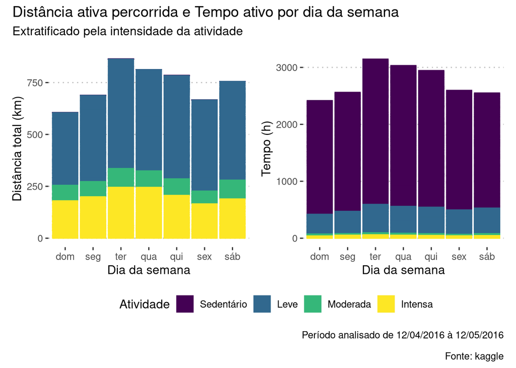

No gráfico abaixo temos a relação entre a distância ativa percorrida e o tempo por atividade. Conseguimos confirmar que por mais que o usuários passem muito tempo sedentários esse tempo não contribui na distância ativa percorrida por dia, também podemos observar que a relação entre distância ativa e tempo de atividade vai crescendo com a intensidade da atividade.

[figure not shown]

Abaixo temos a relação entre tempo da atividade em relação a queima de calorias diárias. verificamos que há uma relação inversa entre o tempo sedentário e a queima de calorias, em contrapartida queima de calorias tem uma relação positiva com a intensidade da atividade.

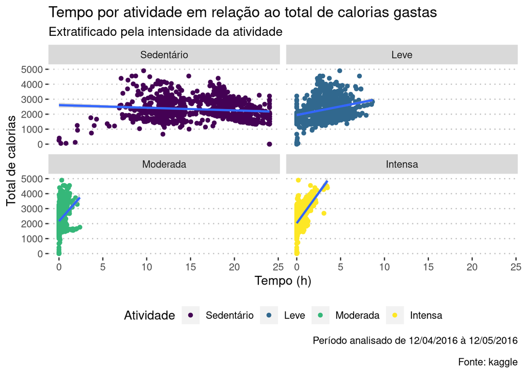

Da mesma forma há uma relação negativa com o tempo sedentário e a quantidade de passos diários totais entre os usuários e uma relação positiva entre a intensidade da atividade com a quantidade de passos diários. Em média, quanto mais sedentário um usuário permanece, menos calorias são gastas e passos são dados durante o dia.

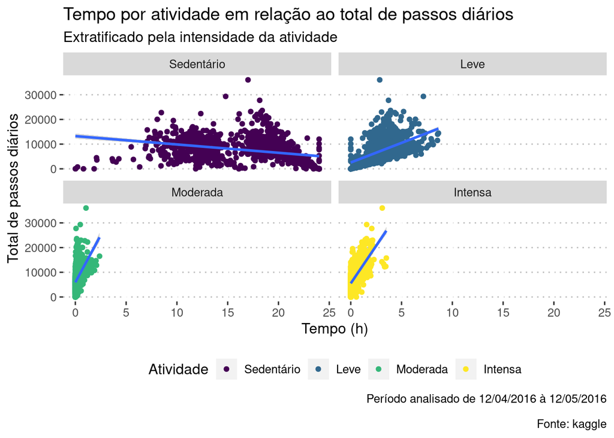

Analisando a relação do quantidade de horas dormidas e os passos diários observamos que usuários que dormem menos de 6 horas diários tendem a queimar menos calorias que usuários dormem de 6 a 10 horas por dia. Observamos também que a relação entre queima de calorias e passos diários não é tão forte entre os usuários que dormem mais de 10 horas diárias, contudo isso pode se dar pela baixa quantidade de usuários nessa faixa de sono o que requer dados adicionais para chegarmos a uma conclusão dessa faixa de usuários. Com os dados disponíveis podemos ver que a relação anterior entre passos diários e queima de calorias é quebrado, fazendo que mesmo que os usuários sejam ativo durante o dia a queima de caloria é diminuída em relação as usuários que tem ua boa relação com as hora de sono.

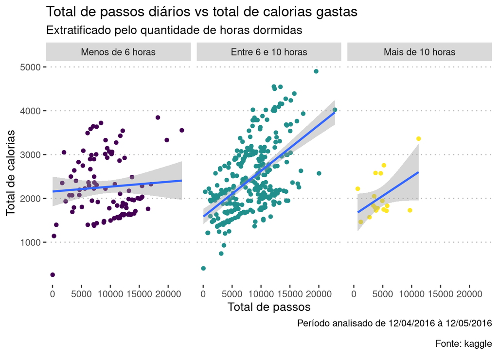

Fazendo um paralelo entre as duração do sono e o média de batimentos cardíacos vemos que usuários que dormem menos de 6 horas diárias tendem a ter uma média batimentos cardíacos mais elevados do que usuários de dormem de 6 à 10 horas diárias. Uma boa noite de sono, ao que indicam os dados podem ajudar a evitar possível doenças cardíacas em pessoas com pré disposição a isso.

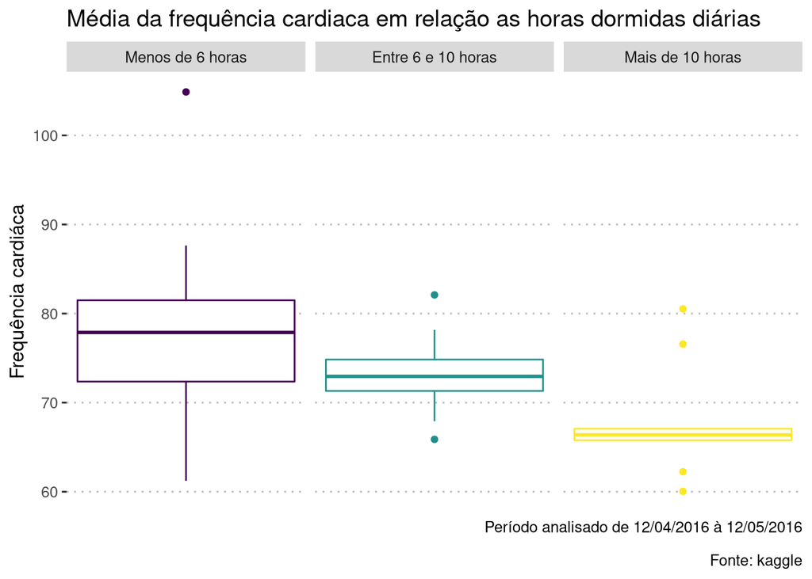

Comparando a média de horas dormidas com o índice de massa corporal médio vemos que usuários que dormem menos de 6 horas tem na média um percentual masa corporal maior que usuários que dormem entre 6 e 10 horas por dia.

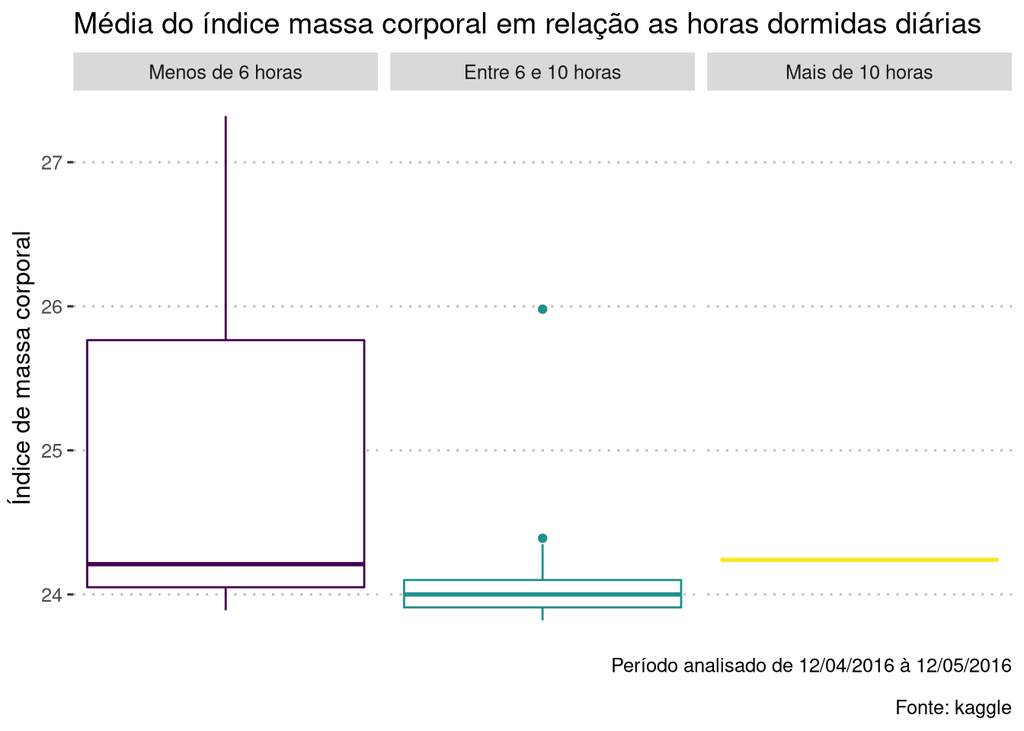

## Resumos do análise

Analisando os dados encontramos as seguintes relações:

- quanto mais tempo um usuário permanece sedentário menos passos/calorias esse usuário percorre/gasta durante o dia;
- a relação entre passos diários, bem como calorias gastas, e o tempo da atividade é positiva e essa relação tende a aumentar com a intensidade da atividade;
- usuários que dormem menos de 6 horas por dia tentem a gastar, em média, menos calorias por dia;
- usuários que dormem menos de 6 horas tendem a ter a frequência cardíaca e o índice de massa corporal maior que usuários que dormem de 6 a 10 horas por dia.